# BMI 585 - Final Project

Hope Mumme

12/9/2021

This Markdown file contains example uses for all the functions in the package bmi585hmumme. You can download the package with the following command in the R Console. Uncomment the following if you have not installed the package to your system.

```r
#devtools::install_github("hmumme/bmi585hmumme")
```

Load the package and set up the Markdown file:

```r
knitr::opts_chunk$set(echo = TRUE)
library(bmi585hmumme)
```

The following functions are broken down by section; each section represents the assignment the function came from. These examples can also be found in the help documentation for each function; type ?functionName to retrieve this.

### newFunctions.R

##### unscale(x)

This function takes a numerical object from scale(), reverses the scaling and centering done (if any), and returns the un-scaled numerical object.

```r
xS = scale(matrix(1:10, ncol = 2)) # scale a matrix
unscale(x = xS) # un-scale to get the original matrix
```

```
##      [,1] [,2]
## [1,]    1    6
## [2,]    2    7
## [3,]    3    8
## [4,]    4    9
## [5,]    5   10
## attr(,"scaled:center")
## [1] 3 8
## attr(,"scaled:scale")
## [1] 1.581139 1.581139
```

##### pcApprox(x,npc)

This function approximates x feature data using npc number of principle components.

```r
x = matrix(c(4,5,2,10,2,8,4,5,6), ncol = 3) # feature data matrix
pcApprox(x, npc = 1) # approximate using 1 principle component
```

```
##          [,1]     [,2]     [,3]
## [1,] 4.077933 6.444833 4.716622
## [2,] 7.150360 4.787590 2.599603
## [3,] 2.560673 7.263231 5.762071
```

##### pcLollipop(x)

This function creates lollipop plots of all the principal component loadings in feature data x (must be numerical data frame or tibble). Each principle component will have its own plot of values for each variable in the data x.

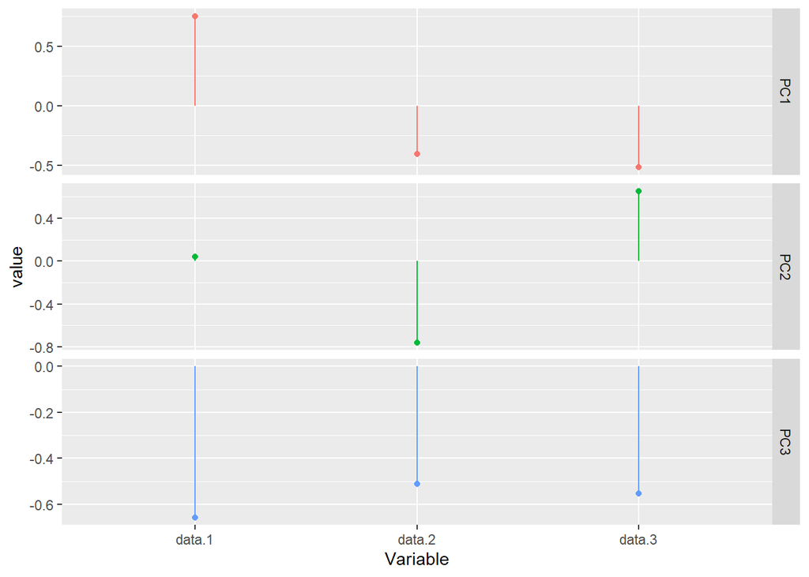

```r
x = data.frame(data = matrix(c(4,5,2,10,2,8,4,5,6), ncol = 3)) # feature data frame
pcLollipop(x) # create lollipop plots
```

### quiz02Functions.R

##### sensitivity(pred,truth)

This function calculates the sensitivity from predicted and true vectors. These vectors can either be 0s (negatives) and 1s (positives) or boolean.

```r
sensitivity(c(0,1,0),c(1,1,1)) # calculates sensitivity
```

```
## [1] 0.3333333
```

##### specificity(pred,truth)

This function calculates the specificity from predicted and true vectors. These vectors can either be 0s (negatives) and 1s (positives) or boolean.

```r
specificity(c(0,1,1),c(0,0,1)) # calculates specificity
```

```
## [1] 0.5
```

##### accuracy(pred,truth)

This function calculates the accuracy from predicted and true vectors. These vectors can either be 0s (negatives) and 1s (positives) or boolean.

```r
accuracy(c(0,1,1),c(1,1,1)) # calculates accuracy
```

```
## [1] 0.6666667
```

##### ppv(pred,truth)

This function calculates the PPV from predicted and true vectors. These vectors can either be 0s (negatives) and 1s (positives) or boolean.

```r
ppv(c(1,1,0),c(0,1,1)) # calculates PPV
```

```
## [1] 0.5
```

##### f1(pred,truth)

This function calculates the F1 score from predicted and true vectors. These vectors can either be 0s (negatives) and 1s (positives) or boolean.

```r
f1(c(1,1,1),c(1,1,0)) # calculates f1 score
```

```
## [1] 0.8
```

### hw04Functions.R

##### boxMuller(n)

This function use the Box-Muller transformation to generate 2 vectors of random, normally distributed n values.

```r
boxMuller(5) # generates two random, normally distributed vectors with 5 values each
```

```
##            [,1]        [,2]
## [1,] -0.7559746 -0.78204977
## [2,]  0.1191227 -0.28155494
## [3,] -1.4754468 -0.88077287
## [4,]  1.4741516  0.66777492
## [5,] -1.6879436  0.07743602
```

### hw06Functions.R

##### twoSidedT(t,n)

This function calculates the p-value from a two-sided t-test statistic and the number of samples n.

```r
twoSidedT(3, 5) # calculates p-value
```

```
## [1] 0.03994197
```

##### twoSizedZ(z)

This function calculates the p-value from a two-sided z score.

```r
twoSidedZ(3) # calculates p-value
```

```
## [1] 0.002699796
```

##### effectSize(x,g)

This function calculates the effect size from vector of values x and grouping variable g.

```r
effectSize(c(1.42, 8.10, 9.22, 20.92, 5.67, 0.45), c(0,0,1,1,0)) # calculates effect size
```

```
## [1] 1.583414
```

##### welchT(x,y)

This function performs a Welch’s T test to compare the means of vector x and vector y. It will return a vector of length 5 with Welch’s T statistic, degrees of freedom, p-value, mean of group x, and mean of group y.

```r
welchT(c(1.42, 8.10, 9.22, 20.92, 5.67, 0.45), c(1.99, 8.09, 9.13, 9.10, 5.55, 0.11)) # calculate welch t-test statistics
```

```
## TestStatistic            DF        pValue         meanX         meanY
##     0.5784263     7.5243010     0.2899357     7.6300000     5.6616667
```

### hw07Functions.R

##### minimumN(d)

This function finds the minimum number of samples needed for effect size d and power = 0.8, returns number of samples rounded up to nearest integer.

```r
minimumN(1.3) # calculate number of samples needed
```

```
## [1] 11
```

##### chiSquareCounts(tib,x,y)

This function performs a chi square test of homogeneity between data in columns x and y of tib. Returns a p-value.

```r
data = dplyr::tibble("sex" = c(1,0,1),"group" = c("A","B","C"), "age" = c(40,15,33), "height" = c(63, 70, 68)) # create data
chiSquareCounts(data, "age", "height") # perform test
```

```
## [1] 0.1991483
```

##### postHocPower(d,n1,n2)

This function estimates post hoc power from effect size and number of samples using 1000 simulations.

```r
postHocPower(d = 0.5, n1 = 20, n2 = 22) # estimate power
```

```
## [1] 0.369
```

### hw08Functions.R

##### bhAdjust(p)

This function tests for significant p-values using Bonferroni-Holm adjustment. Returns logical vector showing which p-values are statistically significant after the BH adjustment.

```r
bhAdjust(c(0.05, 0.0005, 0.01, 0.0225, 0.025)) # find which p-values are significant after BH adjustment
```

```
## [1] FALSE  TRUE  TRUE FALSE FALSE
```

##### fdrAdjust(p)

This function tests for significant p-values using FDR adjustment. Returns logical vector showing which p-values are statistically significant after the FDR adjustment.

```r
fdrAdjust(c(0.05, 0.0005, 0.01, 0.0225, 0.025)) # find which p-values are significant after fdr adjustment
```

```
## [1] FALSE  TRUE  TRUE  TRUE  TRUE
```

### hw11Functions.R

##### r2(pred,truth)

This function calculates the R-Squared value from two numerical vectors of predicted/true values.

```r
yTrue = c(0,1,1,1) # true values
r2(pred = c(0,1,0.7,1), truth = yTrue) # find R^2
```

```
## [1] 0.88
```

##### adjR2(pred,truth)

This function calculates the adjusted R-Squared value from two numerical vectors of predicted/true values and the number of predictors used d.

```r
yTrue = c(0,1,1,1) # true values
adjR2(pred = c(0,1,0.7,1), truth = yTrue, d = 2) # find adjusted R^2
```

```
## [1] 0.64
```